# Education inequality

#### Numerical summaries

$\rightarrow$ Use the `skim` function to examine the basic numerical summaries for each variable.

```r
edgap %>% select(-id) %>% skim()
```

Data summary

| Name | Piped data |
| --- | --- |
| Number of rows | 7230 |
| Number of columns | 10 |
| _______________________ |  |
| Column type frequency: |  |
| character | 4 |
| numeric | 6 |
| ________________________ |  |
| Group variables | None |

**Variable type: character**

| skim_variable | n_missing | complete_rate | min | max | empty | n_unique | whitespace |
| --- | --- | --- | --- | --- | --- | --- | --- |
| state | 0 | 1 | 2 | 2 | 0 | 20 | 0 |
| zip_code | 0 | 1 | 5 | 5 | 0 | 6128 | 0 |
| school_type | 0 | 1 | 14 | 27 | 0 | 4 | 0 |
| school_level | 0 | 1 | 4 | 4 | 0 | 1 | 0 |

**Variable type: numeric**

| skim_variable | n_missing | complete_rate | mean | sd | p0 | p25 | p50 | p75 | p100 | hist |
| --- | --- | --- | --- | --- | --- | --- | --- | --- | --- | --- |
| rate_unemployment | 12 | 1 | 0.10 | 0.06 | 0.00 | 0.06 | 0.08 | 0.12 | 0.59 | ▇▂▁▁▁ |
| percent_college | 11 | 1 | 0.57 | 0.17 | 0.09 | 0.45 | 0.56 | 0.68 | 1.00 | ▁▅▇▅▂ |
| percent_married | 20 | 1 | 0.64 | 0.19 | 0.00 | 0.53 | 0.67 | 0.78 | 1.00 | ▁▂▅▇▃ |
| median_income | 16 | 1 | 52760.47 | 24365.51 | 4833.00 | 37106.00 | 47404.00 | 62106.00 | 226181.00 | ▇▆▁▁▁ |
| average_act | 3 | 1 | 20.30 | 2.51 | 12.36 | 18.80 | 20.50 | 22.00 | 32.36 | ▁▇▇▁▁ |
| percent_lunch | 20 | 1 | 0.41 | 0.23 | 0.00 | 0.23 | 0.37 | 0.56 | 1.00 | ▅▇▆▃▂ |

## Model

Our exploratory data analysis has led to the following observations that will help guide the modeling process:

1. Each of the socioeconomic variables is associated with the ACT score and is worthwhile to consider as a predictor.
2. Some of the socioeconomic variables may have a nonlinear relationship with the ACT score, so nonlinear models should be explored.
3. The socioeconomic variables are correlated with each other, so the best prediction of ACT score might not include all socioeconomic variables.

### Simple linear regression with each socioeconomic predictor

In this project, we are very concerned with understanding the relationships in the data set; we are not only concerned with building a model with the highest prediction accuracy. Therefore, we will start by looking at simple linear regression models using each socioeconomic predictor.

#### Percent free or reduced lunch

**Fit a model**

We want to fit the simple linear regression model

`average_act` $\approx \beta_0 + \beta_1$ `percent_lunch`

Use the function `lm` to fit a simple linear regression model.

```r
fit_pl <- lm(average_act ~ percent_lunch, data = edgap)
```

Use the `summary` function to

1. Interpret the coefficients in the model.
2. Assess the statistical significance of the coefficient on the predictor variable.

```r
summary(fit_pl)$coefficients
```

```
##                Estimate Std. Error  t value Pr(>|t|)
## (Intercept)   23.744781 0.03693874  642.815        0
## percent_lunch -8.393695 0.07814631 -107.410        0
```

The intercept is 23.7 and the slope is -8.39. The intercept is interpreted as the best estimate for the mean ACT score when `percent_lunch` is zero. The slope can be interpreted as saying that a `percent_lunch` increase of 0.1 is associated with a decrease in the estimated mean ACT score of -0.839 points.

The slope is highly statistically significant, as the p-values are reported as zero. So, there is a statistically significant relationship between `percent_lunch` and the average ACT score in a school.

Plot the regression line together with the scatter plot

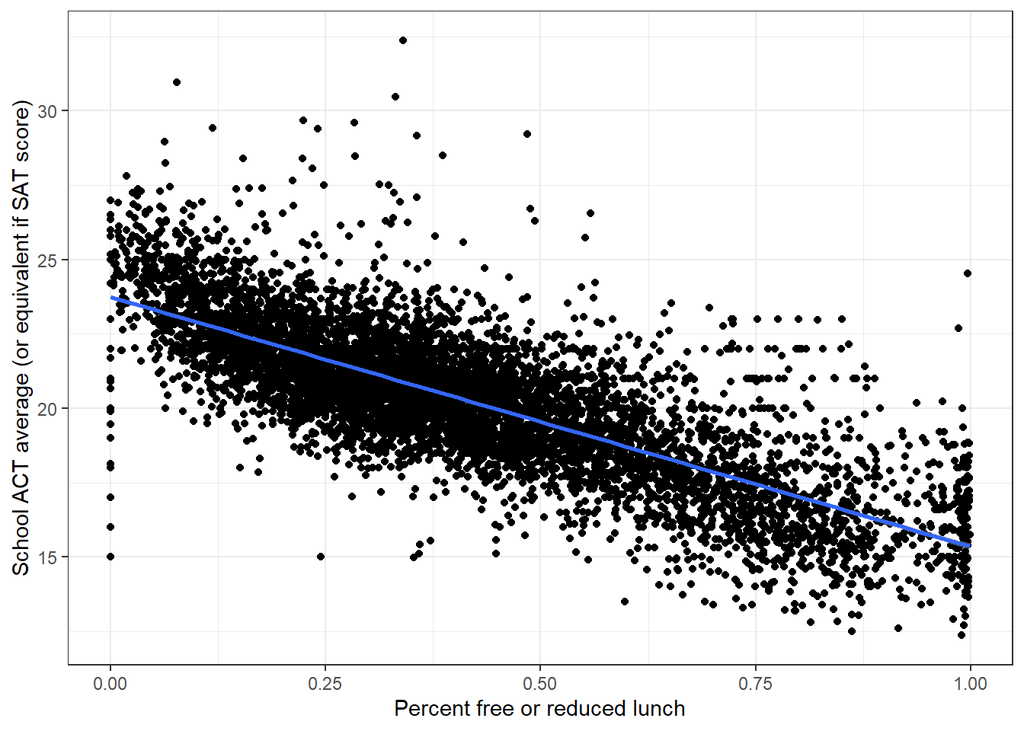

```r
#geom_smooth(method = "lm",formula = y ~ x) adds the regression line to the scatter plot

ggplot(edgap, aes(x = percent_lunch, y = average_act)) +
  geom_point() +
  geom_smooth(method = "lm",formula = y ~ x) +
  labs(x = "Percent free or reduced lunch", y = "School ACT average (or equivalent if SAT score)") +
  theme_bw()
```

**Assess the accuracy of the fit**

Examine the $R^2$ and the residual standard error

```r
summary(fit_pl)$r.squared
```

```
## [1] 0.6155674
```

The simple linear regression model using percent free or reduced lunch as a predictor can explain 61.6% in the variance of the ACT score.

```r
summary(fit_pl)$sigma
```

```
## [1] 1.55522
```

The residual standard error is 1.56 points. This means that the model is off by about 1.56 points, on average.

Together, these results show that we can make a good prediction of the average ACT score in a school only by knowing the percent of students receiving free or reduced lunch.

Note that, in this example, we called different components from the `summary` output individually. We took this approach to walk through each step of the analysis, but you can simply look at the output of `summary(fit_pl)` to see all of the information at once.

**Residual plot**

Examine a residual plot to see if we can improve the model through a transformation of the `percent_lunch` variable.

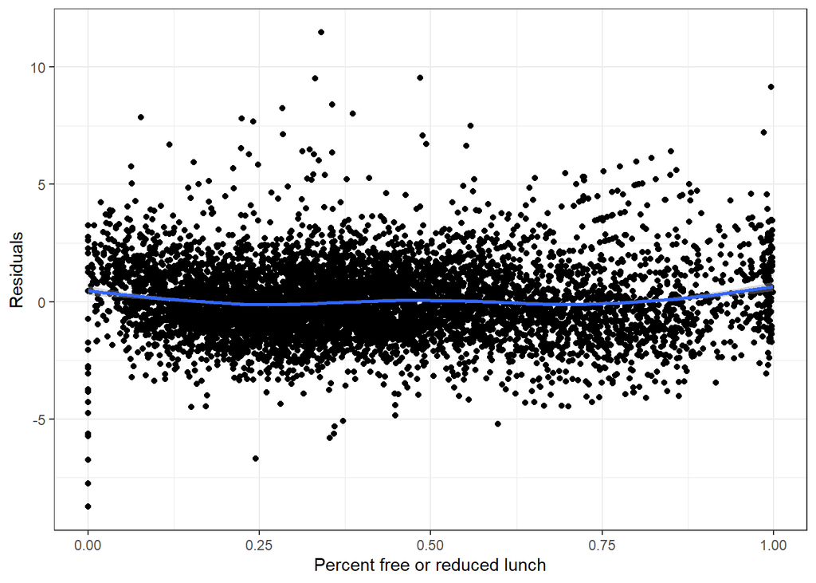

```r
#We will use ggplot2 to make the residual plot. You can also use plot(fit_pl)
ggplot(fit_pl,aes(x=percent_lunch, y=.resid)) +
  geom_point() +
  geom_smooth(method = "loess", formula = y ~ x) +
  labs(x = "Percent free or reduced lunch", y = "Residuals") +
  theme_bw()
```

The residual plot does not have much systematic structure, so we have used `percent_lunch` as well as we can as a predictor. We do not need to consider a more complicated model that only uses `percent_lunch` as an input variable.

#### Median income

**Fit a model**

We want to fit the simple linear regression model

`average_act` $\approx \beta_0 + \beta_1$ `median_income`

$\rightarrow$ Use the function `lm` to fit a simple linear regression model.

```r
fit_mi <- lm(average_act ~ median_income, data = edgap)
```

$\rightarrow$ Use the `summary` function to:

```r
summary(fit_mi)$coefficients
```

```
##                   Estimate   Std. Error   t value Pr(>|t|)
## (Intercept)   1.780119e+01 6.253060e-02 284.67963        0
## median_income 4.733825e-05 1.075819e-06  44.00205        0
```

1. Interpret the coefficients in the model.
2. Assess the statistical significance of the coefficient on the predictor variable.

```r
edgap <- edgap %>%
  mutate(median_income_10k = median_income/1e4)

fit_mi <- lm(average_act ~ median_income_10k, data = edgap)

summary(fit_mi)$coefficients
```

```
##                     Estimate Std. Error   t value Pr(>|t|)
## (Intercept)       17.8011868 0.06253060 284.67963        0
## median_income_10k  0.4733825 0.01075819  44.00205        0
```

$\rightarrow$ Plot the regression line together with the scatter plot

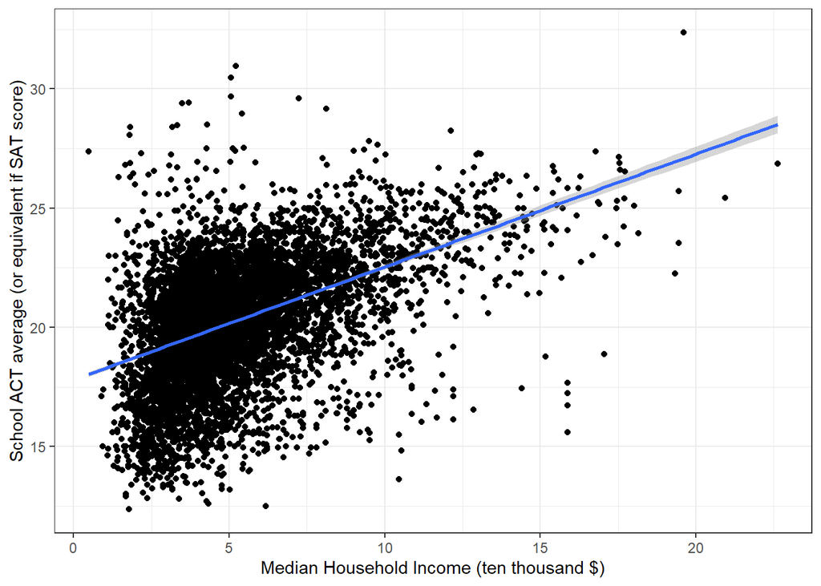

```r
ggplot(edgap, aes(x = median_income_10k, y = average_act)) +
  geom_point() +
  geom_smooth(method = "lm",formula = y ~ x) +
  labs(x = "Median Household Income (ten thousand $)", y = "School ACT average (or equivalent if SAT score)") +
  theme_bw()
```

**Assess the accuracy of the fit**

$\rightarrow$ Examine the $R^2$ and the residual standard error

```r
summary(fit_mi)$r.squared
```

```
## [1] 0.2117159
```

```r
summary(fit_mi)$sigma
```

```
## [1] 2.225708
```

**Residual plot**

$\rightarrow$ Examine a residual plot to see if we can improve the model through a transformation of the `median_income_10` variable.

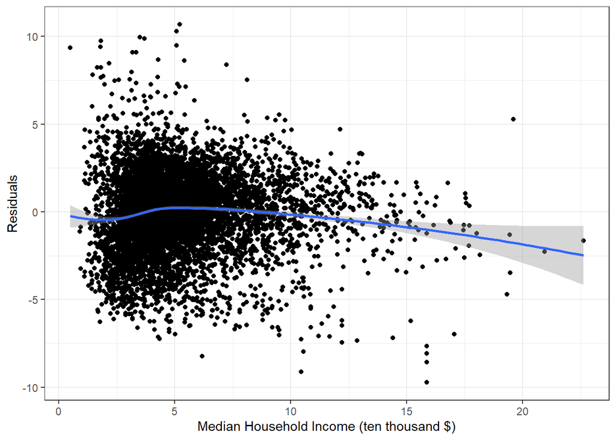

```r
ggplot(fit_mi,aes(x=median_income_10k, y=.resid)) +
  geom_point() +
  geom_smooth(method = "loess", formula = y ~ x) +
  labs(x = "Median Household Income (ten thousand $)", y = "Residuals") +
  theme_bw()
```

**Log transformation**

**Fit the model**

$\rightarrow$ Fit a linear regression model using the log of `median_income_10` as the predictor.

```r
fit_mi_log <- lm(average_act ~ log10(median_income_10k), data = edgap)
```

$\rightarrow$ Use the `summary` function to:

1. Interpret the coefficients in the model.
2. Assess the statistical significance of the coefficient on the predictor variable.

```r
summary(fit_mi_log)$coefficients
```

```
##                           Estimate Std. Error   t value Pr(>|t|)
## (Intercept)              16.040603 0.09908011 161.89529        0
## log10(median_income_10k)  6.245003 0.14014512  44.56097        0
```

$\rightarrow$ Plot the regression line together with the scatter plot

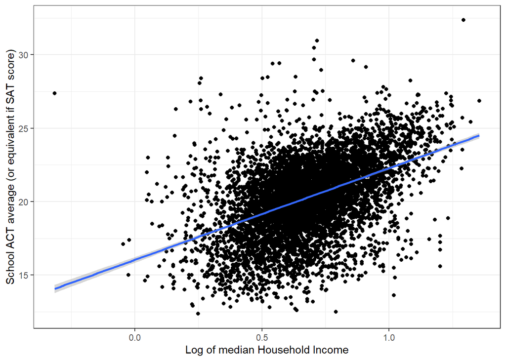

```r
ggplot(edgap, aes(x = log10(median_income_10k), y = average_act)) +
  geom_point() +
  geom_smooth(method = "lm",formula = y ~ x) +
  labs(x = "Log of median Household Income", y = "School ACT average (or equivalent if SAT score)") +
  theme_bw()
```

**Assess the accuracy of the fit**

$\rightarrow$ Examine the $R^2$ and the residual standard error

```r
summary(fit_mi_log)$r.squared
```

```
## [1] 0.2159597
```

```r
summary(fit_mi_log)$sigma
```

```
## [1] 2.219709
```

**Residual plot**

$\rightarrow$ Examine a residual plot to see if we can improve the model through a transformation of the input.

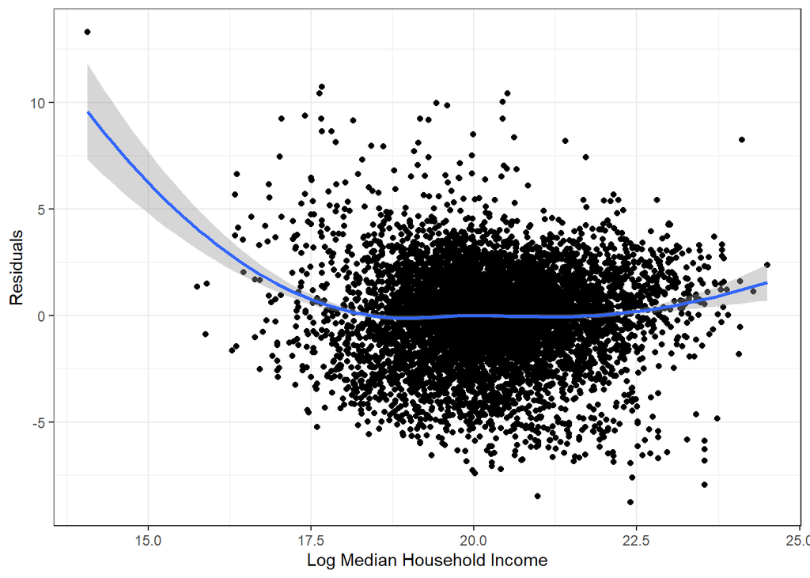

```r
ggplot(fit_mi_log, aes(x=.fitted, y=.resid)) +
  geom_point() +
  geom_smooth(method = "loess", formula = y ~ x) +
  labs(x = "Log Median Household Income", y = "Residuals") +
  theme_bw()
```

#### Percent college

**Fit a model**

We want to fit the simple linear regression model

`average_act` $\approx \beta_0 + \beta_1$ `percent_college`

$\rightarrow$ Use the function `lm` to fit a simple linear regression model.

```r
fit_pc <- lm(average_act ~ percent_college, data = edgap)
```

$\rightarrow$ Use the `summary` function to

1. Interpret the coefficients in the model.
2. Assess the statistical significance of the coefficient on the predictor variable.

```r
summary(fit_pc)$coefficients
```

```
##                  Estimate Std. Error   t value Pr(>|t|)
## (Intercept)     16.307759 0.09476034 172.09477        0
## percent_college  6.966002 0.15889860  43.83929        0
```

$\rightarrow$ Plot the regression line together with the scatter plot

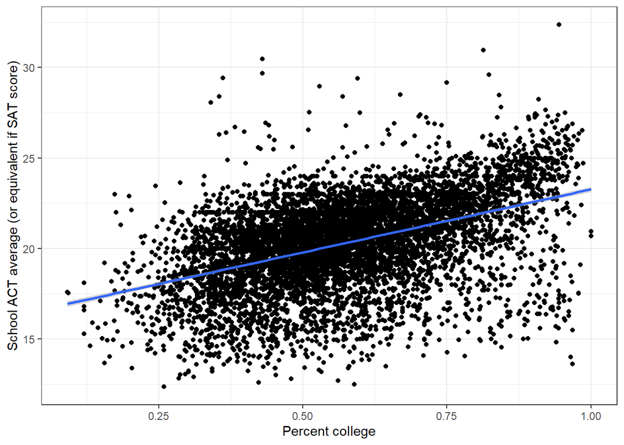

```r
ggplot(edgap, aes(x = percent_college, y = average_act)) +
  geom_point() +
  geom_smooth(method = "lm",formula = y ~ x) +
  labs(x = "Percent college", y = "School ACT average (or equivalent if SAT score)") +
  theme_bw()
```

**Assess the accuracy of the fit**

$\rightarrow$ Examine the $R^2$ and the residual standard error

```r
summary(fit_pc)$r.squared
```

```
## [1] 0.2103665
```

```r
summary(fit_pc)$sigma
```

```
## [1] 2.227256
```

**Residual plot**

$\rightarrow$ Examine a residual plot to see if we can improve the model through a transformation of the input variable.

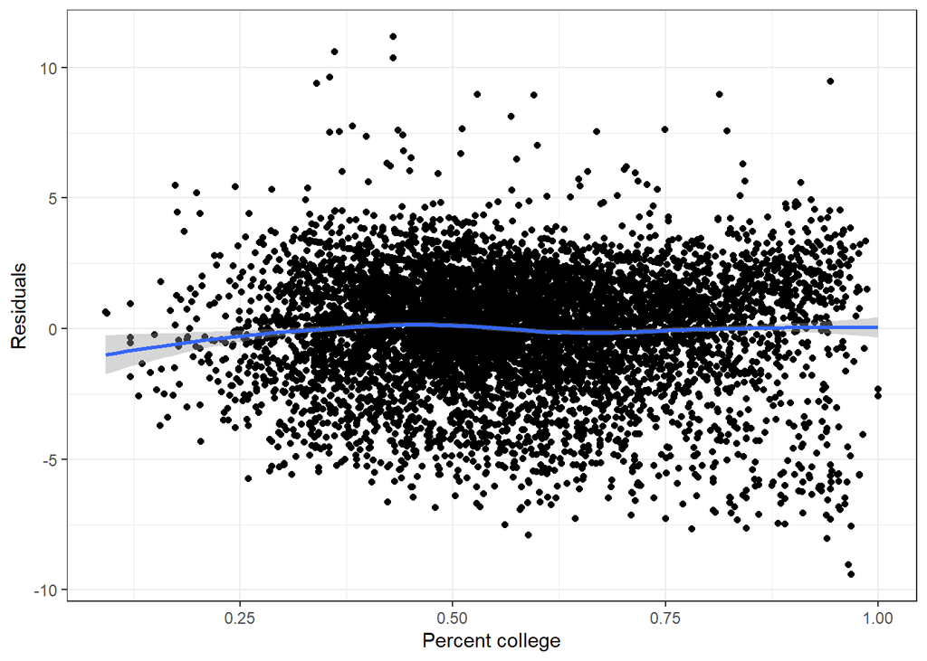

```r
ggplot(fit_pc, aes(x=percent_college, y=.resid)) +
  geom_point() +
  geom_smooth(method = "loess", formula = y ~ x) +
  labs(x = "Percent college", y = "Residuals") +
  theme_bw()
```

$\rightarrow$ Fit and assess a quadratic model

```r
fit_pc_quad <- lm(average_act ~ poly(percent_college,2, raw = T), data = edgap)
summary(fit_pc_quad)
```

```
##
## Call:
## lm(formula = average_act ~ poly(percent_college, 2, raw = T),
##     data = edgap)
##
## Residuals:
##     Min      1Q  Median      3Q     Max
## -9.3502 -1.2283  0.2854  1.4668 11.1775
##
## Coefficients:
##                                    Estimate Std. Error t value Pr(>|t|)
## (Intercept)                         16.1091     0.2686  59.980   <2e-16 ***
## poly(percent_college, 2, raw = T)1   7.6930     0.9333   8.242   <2e-16 ***
## poly(percent_college, 2, raw = T)2  -0.6129     0.7754  -0.790    0.429
## ---
## Signif. codes:  0 '***' 0.001 '**' 0.01 '*' 0.05 '.' 0.1 ' ' 1
##
## Residual standard error: 2.227 on 7213 degrees of freedom
##   (14 observations deleted due to missingness)
## Multiple R-squared:  0.2104, Adjusted R-squared:  0.2102
## F-statistic: 961.2 on 2 and 7213 DF,  p-value: < 2.2e-16
```

#### Rate of unemployment

**Fit a model**

We want to fit the simple linear regression model

`average_act` $\approx \beta_0 + \beta_1$ `rate_unemployment`

$\rightarrow$ Use the function `lm` to fit a simple linear regression model.

```r
fit_ru <- lm(average_act ~ rate_unemployment, data = edgap)
```

$\rightarrow$ Use the `summary` function to:

1. Interpret the coefficients in the model.
2. Assess the statistical significance of the coefficient on the predictor variable.

```r
summary(fit_ru)$coefficients
```

```
##                    Estimate Std. Error   t value Pr(>|t|)
## (Intercept)        22.15006 0.05252349 421.71719        0
## rate_unemployment -19.19084 0.46971479 -40.85636        0
```

$\rightarrow$ Plot the regression line together with the scatter plot

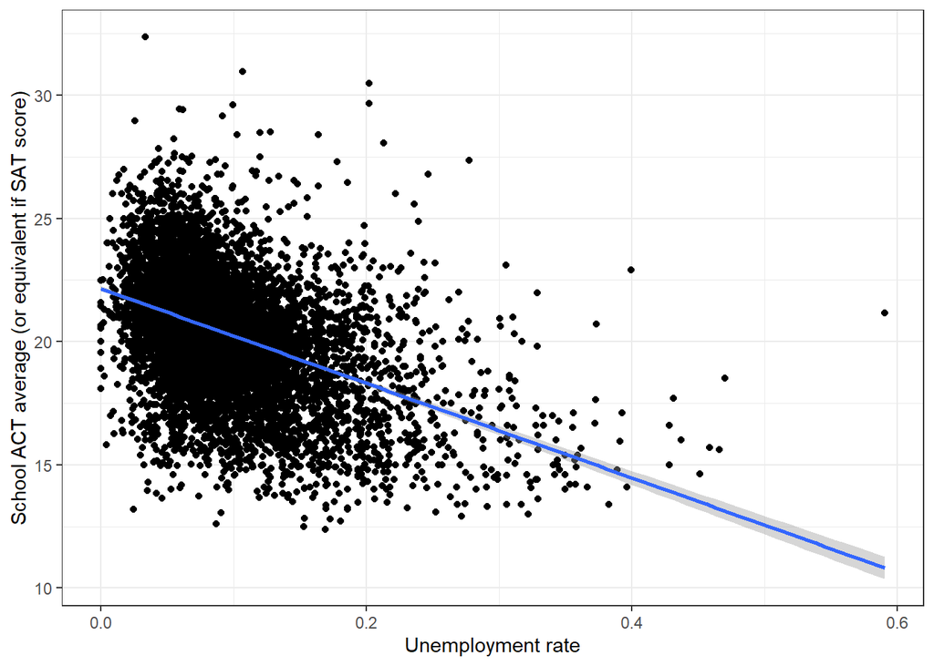

```r
ggplot(edgap, aes(x = rate_unemployment, y = average_act)) +
  geom_point() +
  geom_smooth(method = "lm",formula = y ~ x) +
  labs(x = "Unemployment rate", y = "School ACT average (or equivalent if SAT score)") +
  theme_bw()
```

**Assess the accuracy of the fit**

$\rightarrow$ Examine the $R^2$ and the residual standard error

```r
summary(fit_ru)$r.squared
```

```
## [1] 0.1879303
```

```r
summary(fit_ru)$sigma
```

```
## [1] 2.258699
```

**Residual plot**

$\rightarrow$ Examine a residual plot to see if we can improve the model.

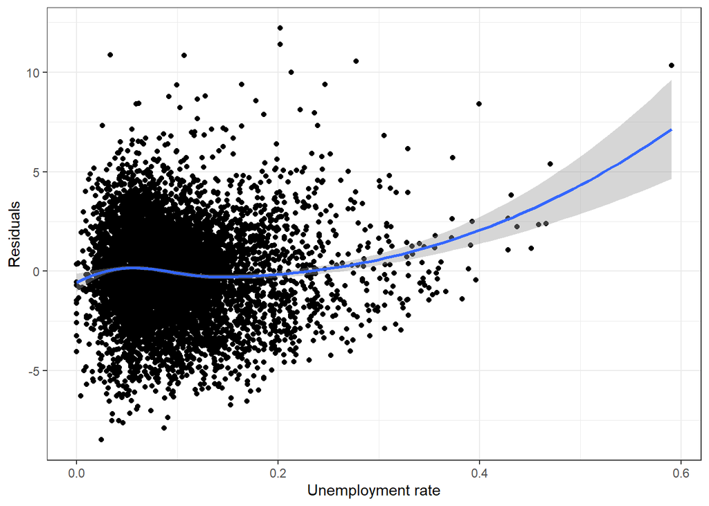

```r
ggplot(fit_ru,aes(x=rate_unemployment, y=.resid)) +
  geom_point() +
  geom_smooth(method = "loess", formula = y ~ x) +
  labs(x = "Unemployment rate", y = "Residuals") +
  theme_bw()
```

```r
fit_ru_sqrt <- lm(average_act ~ sqrt(rate_unemployment), data = edgap)
summary(fit_ru_sqrt)
```

```
##
## Call:
## lm(formula = average_act ~ sqrt(rate_unemployment), data = edgap)
##
## Residuals:
##     Min      1Q  Median      3Q     Max
## -8.9088 -1.3999  0.0888  1.4304 12.1059
##
## Coefficients:
##                          Estimate Std. Error t value Pr(>|t|)
## (Intercept)              24.09827    0.09705   248.3   <2e-16 ***
## sqrt(rate_unemployment) -12.72070    0.31252   -40.7   <2e-16 ***
## ---
## Signif. codes:  0 '***' 0.001 '**' 0.01 '*' 0.05 '.' 0.1 ' ' 1
##
## Residual standard error: 2.26 on 7213 degrees of freedom
##   (15 observations deleted due to missingness)
## Multiple R-squared:  0.1868, Adjusted R-squared:  0.1867
## F-statistic:  1657 on 1 and 7213 DF,  p-value: < 2.2e-16
```

Try a square root transformation of `rate_unemployment`

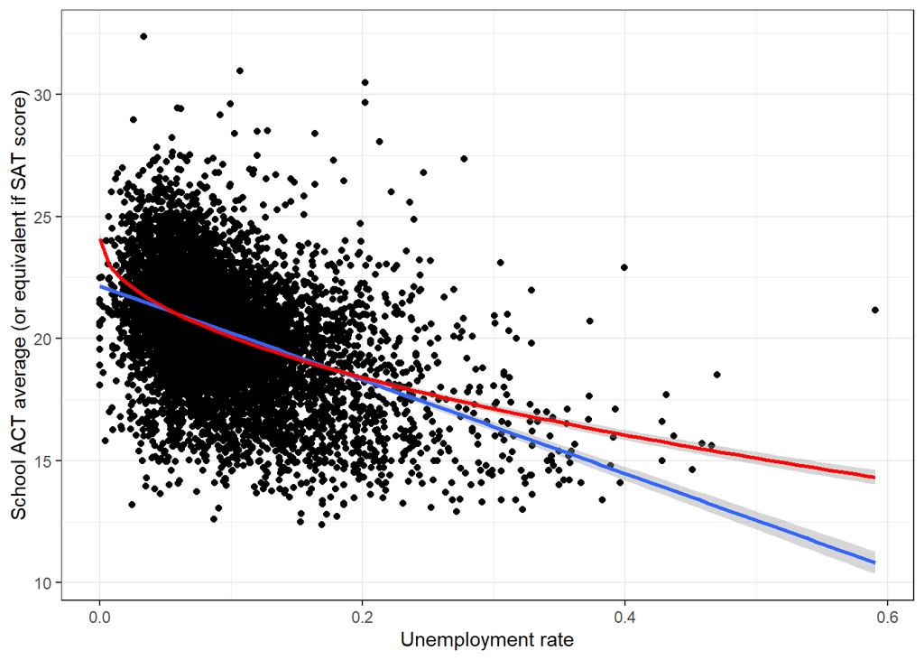

```r
ggplot(edgap, aes(x = rate_unemployment, y = average_act)) +
  geom_point() +
  geom_smooth(method = "lm", formula = y ~ x) +
  geom_smooth(method = "lm", formula = y ~ sqrt(x),color = 'red') +
  labs(x = "Unemployment rate", y = "School ACT average (or equivalent if SAT score)") +
  theme_bw()
```

#### Percent married

**Fit a model**

We want to fit the simple linear regression model

`average_act` $\approx \beta_0 + \beta_1$ `percent_married`

$\rightarrow$ Use the function `lm` to fit a simple linear regression model.

```r
fit_pm <- lm(average_act ~ percent_married, data = edgap)
```

$\rightarrow$ Use the `summary` function to:

1. Interpret the coefficients in the model.
2. Assess the statistical significance of the coefficient on the predictor variable.

```r
summary(fit_pm)$coefficients
```

```
##                  Estimate Std. Error   t value Pr(>|t|)
## (Intercept)     16.599927 0.09268168 179.10690        0
## percent_married  5.774247 0.13862735  41.65301        0
```

$\rightarrow$ Plot the regression line together with the scatter plot

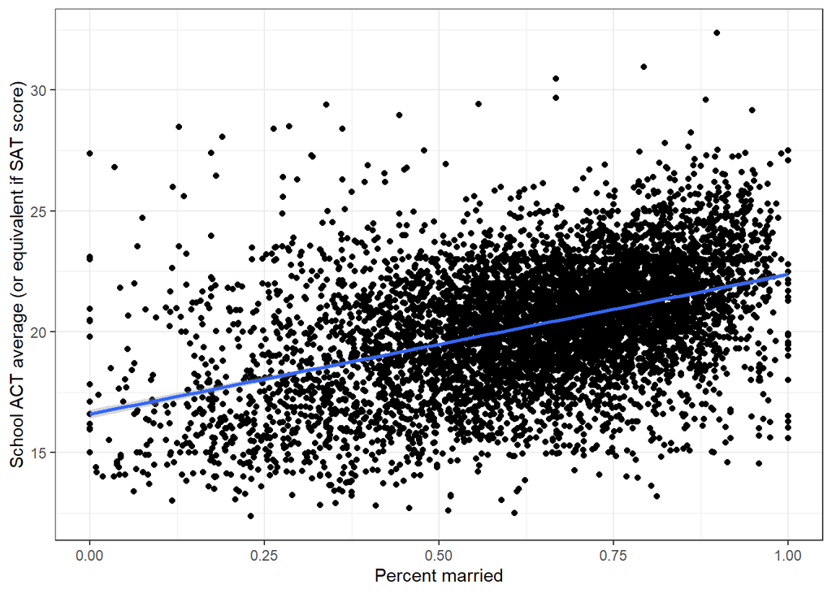

```r
ggplot(edgap, aes(x = percent_married, y = average_act)) +
  geom_point() +
  geom_smooth(method = "lm",formula = y ~ x) +
  labs(x = "Percent married", y = "School ACT average (or equivalent if SAT score)") +
  theme_bw()
```

**Assess the accuracy of the fit**

$\rightarrow$ Examine the $R^2$ and the residual standard error

```r
summary(fit_pm)$r.squared
```

```
## [1] 0.1940692
```

```r
summary(fit_pm)$sigma
```

```
## [1] 2.250251
```

**Residual plot**

$\rightarrow$ Examine a residual plot to see if we can improve the model.

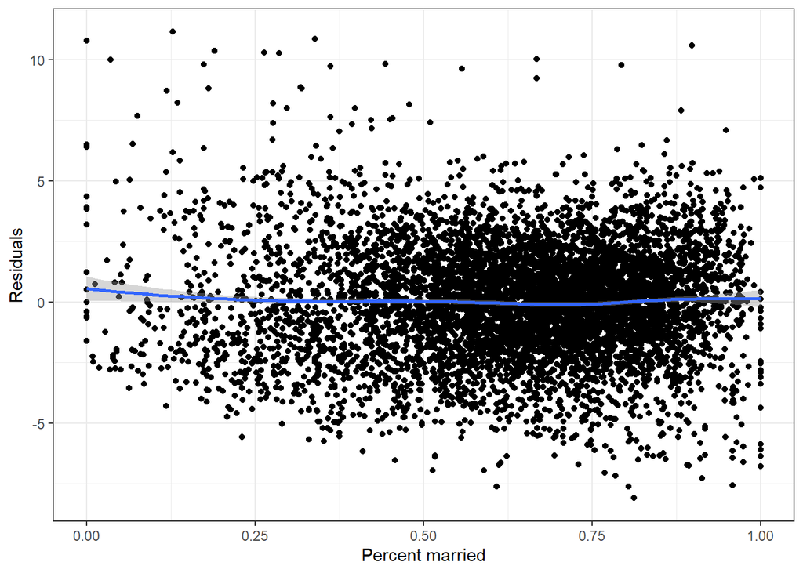

```r
ggplot(fit_pm,aes(x=percent_married, y=.resid)) +
  geom_point() +
  geom_smooth(method = "loess", formula = y ~ x) +
  labs(x = "Percent married", y = "Residuals") +
  theme_bw()
```

### Model selection

Now that understand how each variable is individually related to the ACT score, we want to know how to best use all of the socioeconomic variables to predict the ACT score.

We do not have many input variables, so we can examine the full model.

```r
fit_full <- lm(average_act ~ percent_lunch + median_income + rate_unemployment + percent_college + percent_married, data = edgap)
```

Examine the summary of the fit

```r
summary(fit_full)
```

```
##
## Call:
## lm(formula = average_act ~ percent_lunch + median_income + rate_unemployment +
##     percent_college + percent_married, data = edgap)
##
## Residuals:
##     Min      1Q  Median      3Q     Max
## -8.5334 -0.9347 -0.0858  0.8578 10.7692
##
## Coefficients:
##                     Estimate Std. Error t value Pr(>|t|)
## (Intercept)        2.269e+01  1.371e-01 165.492  < 2e-16 ***
## percent_lunch     -7.604e+00  9.650e-02 -78.801  < 2e-16 ***
## median_income     -1.081e-07  1.205e-06  -0.090    0.929
## rate_unemployment -2.324e+00  4.065e-01  -5.717 1.13e-08 ***
## percent_college    1.754e+00  1.570e-01  11.171  < 2e-16 ***
## percent_married   -7.501e-02  1.332e-01  -0.563    0.573
## ---
## Signif. codes:  0 '***' 0.001 '**' 0.01 '*' 0.05 '.' 0.1 ' ' 1
##
## Residual standard error: 1.522 on 7181 degrees of freedom
##   (43 observations deleted due to missingness)
## Multiple R-squared:  0.6316, Adjusted R-squared:  0.6314
## F-statistic:  2463 on 5 and 7181 DF,  p-value: < 2.2e-16
```

The coefficients for `median_income` and `percent_married` are not statistically significant. Additionally, the sign of the coefficients for `median_income` and `percent_married` do not make sense. These results support removing `median_income` and `percent_married` from the model.

#### Do best subset selection

Use the `regsubsets` function from the `leaps` package to perform best subset selection in order to choose the best model to predict `average_act` from the socioeconomic predictors.

```r
#perform best subset selection
regfit_full <- regsubsets(average_act ~ percent_lunch + median_income + rate_unemployment + percent_college + percent_married, data = edgap)
```

Get the summary of the best subset selection analysis

```r
reg_summary <- summary(regfit_full)
```

What is the best model obtained according to Cp, BIC, and adjusted $R^2$? Make a plot of Cp, BIC, and adjusted $R^2$ vs. the number of variables in the model.

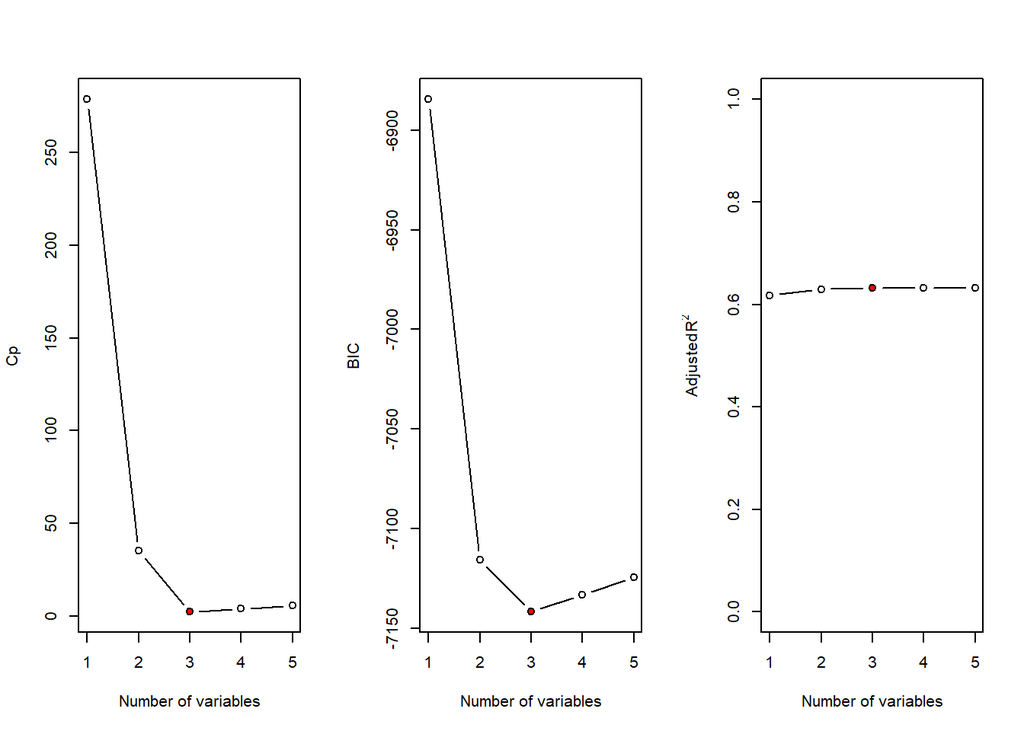

```r
#Set up a three panel plot
par(mfrow = c(1,3))

#Plot Cp
plot(reg_summary$cp,type = "b",xlab = "Number of variables",ylab = "Cp")
#Identify the minimum Cp
ind_cp = which.min(reg_summary$cp)
points(ind_cp, reg_summary$cp[ind_cp],col = "red",pch = 20)

#Plot BIC
plot(reg_summary$bic,type = "b",xlab = "Number of variables",ylab = "BIC")
#Identify the minimum BIC
ind_bic = which.min(reg_summary$bic)
points(ind_bic, reg_summary$bic[ind_bic],col = "red",pch = 20)

#Plot adjusted R^2
plot(reg_summary$adjr2,type = "b",xlab = "Number of variables",ylab = TeX('Adjusted $R^2$'),ylim = c(0,1))

#Identify the maximum adjusted R^2
ind_adjr2 = which.max(reg_summary$adjr2)
points(ind_adjr2, reg_summary$adjr2[ind_adjr2],col = "red",pch = 20)
```

The three measures agree that the best model has three variables.

Show the best model for each possible number of variables. Focus on the three variable model.

```r
reg_summary$outmat
```

```
##          percent_lunch median_income rate_unemployment percent_college
## 1  ( 1 ) "*"           " "           " "               " "
## 2  ( 1 ) "*"           " "           " "               "*"
## 3  ( 1 ) "*"           " "           "*"               "*"
## 4  ( 1 ) "*"           " "           "*"               "*"
## 5  ( 1 ) "*"           "*"           "*"               "*"
##          percent_married
## 1  ( 1 ) " "
## 2  ( 1 ) " "
## 3  ( 1 ) " "
## 4  ( 1 ) "*"
## 5  ( 1 ) "*"
```

The best model uses the predictors `percent_lunch`, `rate_unemployment` and `percent_college`.

Fit the best model and examine the results

```r
fit_best <- lm(average_act ~ percent_lunch + rate_unemployment + percent_college, data = edgap)
```

```r
summary(fit_best)
```

```
##
## Call:
## lm(formula = average_act ~ percent_lunch + rate_unemployment +
##     percent_college, data = edgap)
##
## Residuals:
##     Min      1Q  Median      3Q     Max
## -8.4923 -0.9363 -0.0886  0.8611 10.7536
##
## Coefficients:
##                   Estimate Std. Error t value Pr(>|t|)
## (Intercept)       22.62497    0.10206 221.688  < 2e-16 ***
## percent_lunch     -7.59143    0.09212 -82.405  < 2e-16 ***
## rate_unemployment -2.13118    0.37252  -5.721  1.1e-08 ***
## percent_college    1.73653    0.12637  13.741  < 2e-16 ***
## ---
## Signif. codes:  0 '***' 0.001 '**' 0.01 '*' 0.05 '.' 0.1 ' ' 1
##
## Residual standard error: 1.522 on 7191 degrees of freedom
##   (35 observations deleted due to missingness)
## Multiple R-squared:  0.6311, Adjusted R-squared:  0.631
## F-statistic:  4101 on 3 and 7191 DF,  p-value: < 2.2e-16
```

#### Relative importance of predictors

To compare the magnitude of the coefficients, we should first normalize the predictors. Each of the predictors `percent_lunch`, `rate_unemployment` and `percent_college` is limited to the interval (0,1), but they occupy different parts of the interval. We can normalize each variable through a z-score transformation:

```r
scale_z <- function(x, na.rm = TRUE) (x - mean(x, na.rm = na.rm)) / sd(x, na.rm)

edgap_z <- edgap %>%
  mutate_at(c("percent_lunch","rate_unemployment","percent_college"),scale_z)
```

$\rightarrow$ Fit the model using the transformed variables and examine the coefficients

```r
fit_z <- lm(average_act ~ percent_lunch + rate_unemployment + percent_college, data = edgap_z)
summary(fit_z)
```

```
##
## Call:
## lm(formula = average_act ~ percent_lunch + rate_unemployment +
##     percent_college, data = edgap_z)
##
## Residuals:
##     Min      1Q  Median      3Q     Max
## -8.4923 -0.9363 -0.0886  0.8611 10.7536
##
## Coefficients:
##                   Estimate Std. Error  t value Pr(>|t|)
## (Intercept)       20.29713    0.01795 1130.931  < 2e-16 ***
## percent_lunch     -1.78055    0.02161  -82.405  < 2e-16 ***
## rate_unemployment -0.12065    0.02109   -5.721  1.1e-08 ***
## percent_college    0.28665    0.02086   13.741  < 2e-16 ***
## ---
## Signif. codes:  0 '***' 0.001 '**' 0.01 '*' 0.05 '.' 0.1 ' ' 1
##
## Residual standard error: 1.522 on 7191 degrees of freedom
##   (35 observations deleted due to missingness)
## Multiple R-squared:  0.6311, Adjusted R-squared:  0.631
## F-statistic:  4101 on 3 and 7191 DF,  p-value: < 2.2e-16
```

## Additional step

$\rightarrow$ First we load in the NSES data and join it with the edgap data

```r
Public_Schools <- read_excel("Public Schools.xlsx")

view(Public_Schools)
```

```r
edgap <- edgap %>%
  left_join(Public_Schools, by = "id") %>%
  select(-ends_with(".y"), -ends_with(".x")) %>%
  filter(st_ratio <= 50) %>%
  filter(is.na(average_act) == FALSE)
```

$\rightarrow$ We use the function lm to fit a simple linear regression model and look at the summary.

```r
fit_st <- lm(average_act ~ st_ratio, data=edgap)
summary(fit_st)
```

```
##
## Call:
## lm(formula = average_act ~ st_ratio, data = edgap)
##
## Residuals:
##     Min      1Q  Median      3Q     Max
## -7.6850 -1.4530  0.2117  1.5090 10.2230
##
## Coefficients:
##              Estimate Std. Error t value Pr(>|t|)
## (Intercept) 20.143375   0.123535 163.058  < 2e-16 ***
## st_ratio     0.022302   0.007412   3.009  0.00263 **
## ---
## Signif. codes:  0 '***' 0.001 '**' 0.01 '*' 0.05 '.' 0.1 ' ' 1
##
## Residual standard error: 2.361 on 6250 degrees of freedom
## Multiple R-squared:  0.001446,   Adjusted R-squared:  0.001287
## F-statistic: 9.053 on 1 and 6250 DF,  p-value: 0.002634
```

$\rightarrow$ Plotting the regression line together with the scatter plot

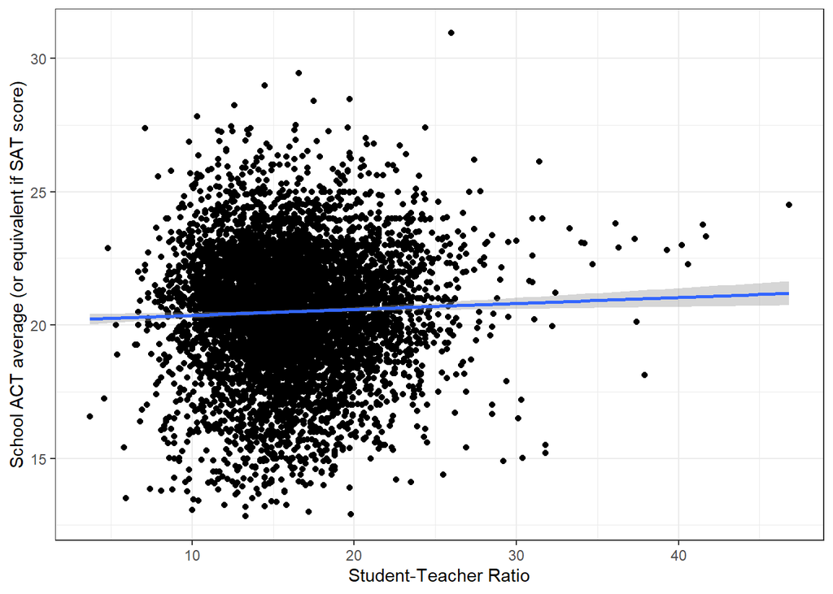

```r
ggplot(edgap, aes(x = st_ratio, y = average_act)) +
  geom_point() +
  geom_smooth(method = "lm",formula = y ~ x) +
  labs(x = "Student-Teacher Ratio", y = "School ACT average (or equivalent if SAT score)") +
  theme_bw()
```

$\rightarrow$ Assessing the accuracy of the fit

```r
summary(fit_st)$r.squared
```

```
## [1] 0.001446322
```

```r
summary(fit_st)$sigma
```

```
## [1] 2.361013
```

$\rightarrow$ Residual plot

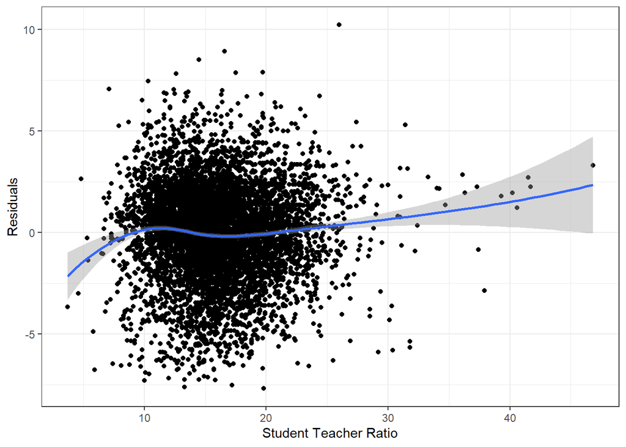

```r
ggplot(fit_st,aes(x=st_ratio, y=.resid)) +
  geom_point() +
  geom_smooth(method = "loess", formula = y ~ x) +
  labs(x = "Student Teacher Ratio", y = "Residuals") +
  theme_bw()
```

$\rightarrow$ Perfomring the best subset selection

```r
#perform best subset selection
regfit_full <- regsubsets(average_act ~ percent_lunch + median_income + rate_unemployment + percent_college + percent_married + st_ratio, data = edgap)
```

$\rightarrow$ Get the summary of the best subset selection analysis

```r
reg_summary <- summary(regfit_full)
```

$\rightarrow$ Looking at what the best model obtained according to Cp, BIC, and adjusted $R^2$?

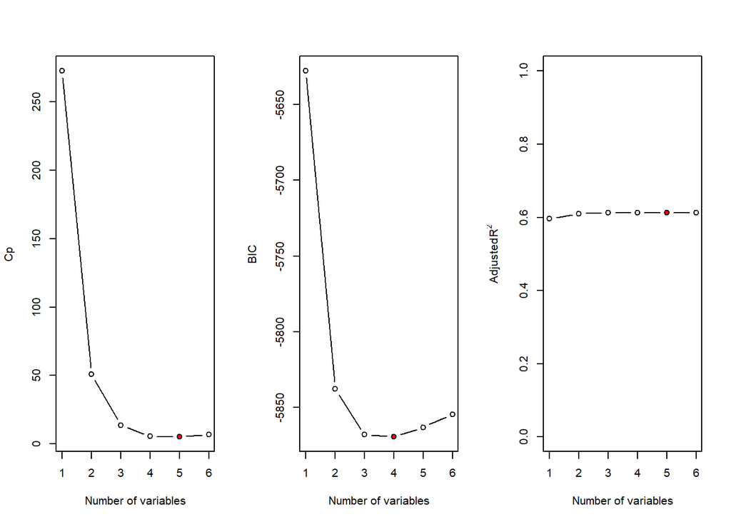

```r
#Set up a three panel plot
par(mfrow = c(1,3))

#Plot Cp
plot(reg_summary$cp,type = "b",xlab = "Number of variables",ylab = "Cp")
#Identify the minimum Cp
ind_cp = which.min(reg_summary$cp)
points(ind_cp, reg_summary$cp[ind_cp],col = "red",pch = 20)

#Plot BIC
plot(reg_summary$bic,type = "b",xlab = "Number of variables",ylab = "BIC")
#Identify the minimum BIC
ind_bic = which.min(reg_summary$bic)
points(ind_bic, reg_summary$bic[ind_bic],col = "red",pch = 20)

#Plot adjusted R^2
plot(reg_summary$adjr2,type = "b",xlab = "Number of variables",ylab = TeX('Adjusted $R^2$'),ylim = c(0,1))

#Identify the maximum adjusted R^2
ind_adjr2 = which.max(reg_summary$adjr2)
points(ind_adjr2, reg_summary$adjr2[ind_adjr2],col = "red",pch = 20)
```

Out of these three models, the best model would be using a BIC model with four variables

$\rightarrow$ Showing the best model for each possible number of variables.

```r
reg_summary$outmat
```

```
##          percent_lunch median_income rate_unemployment percent_college
## 1  ( 1 ) "*"           " "           " "               " "
## 2  ( 1 ) "*"           " "           " "               "*"
## 3  ( 1 ) "*"           " "           "*"               "*"
## 4  ( 1 ) "*"           " "           "*"               "*"
## 5  ( 1 ) "*"           " "           "*"               "*"
## 6  ( 1 ) "*"           "*"           "*"               "*"
##          percent_married st_ratio
## 1  ( 1 ) " "             " "
## 2  ( 1 ) " "             " "
## 3  ( 1 ) " "             " "
## 4  ( 1 ) " "             "*"
## 5  ( 1 ) "*"             "*"
## 6  ( 1 ) "*"             "*"
```

```r
coef(regfit_full,4)
```

```
##       (Intercept)     percent_lunch rate_unemployment   percent_college
##       22.39628822       -7.31830246       -2.69182414        1.72216063
##          st_ratio
##        0.01502911
```

$\rightarrow$ Fitting the best model and examine the results

```r
fit_best <- lm(average_act ~ percent_lunch + rate_unemployment + percent_college + st_ratio, data = edgap)
summary(fit_best)
```

```
##
## Call:
## lm(formula = average_act ~ percent_lunch + rate_unemployment +
##     percent_college + st_ratio, data = edgap)
##
## Residuals:
##     Min      1Q  Median      3Q     Max
## -8.4545 -0.9024 -0.0599  0.8665  8.5543
##
## Coefficients:
##                    Estimate Std. Error t value Pr(>|t|)
## (Intercept)       22.390683   0.125539 178.357  < 2e-16 ***
## percent_lunch     -7.325081   0.103753 -70.601  < 2e-16 ***
## rate_unemployment -2.557143   0.403443  -6.338 2.49e-10 ***
## percent_college    1.734023   0.138001  12.565  < 2e-16 ***
## st_ratio           0.014352   0.004704   3.051  0.00229 **
## ---
## Signif. codes:  0 '***' 0.001 '**' 0.01 '*' 0.05 '.' 0.1 ' ' 1
##
## Residual standard error: 1.47 on 6224 degrees of freedom
##   (23 observations deleted due to missingness)
## Multiple R-squared:  0.6126, Adjusted R-squared:  0.6124
## F-statistic:  2461 on 4 and 6224 DF,  p-value: < 2.2e-16
```

## Conclusion

[output not shown]

After completing your analyses, you will make your conclusions and communicate your results. Consult Canvas for further directions.